# Chapter 1: Foundations of Statistical Modelling Demonstrated with Simple Regression

### Research Example

#### Figure 1.1 R Code - Examining our data

Here we will visualize the distribution of profit. Since profit is a continuous variable, we can graph its distribution with a boxplot and a histogram.

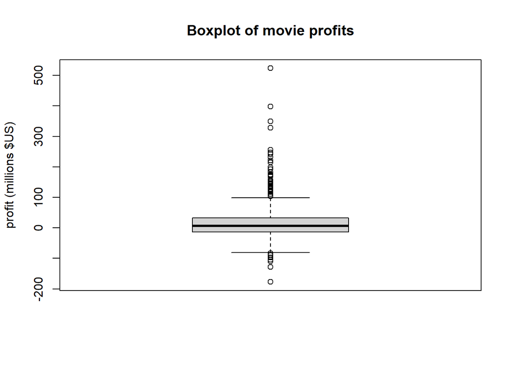

```r
#Creating a boxplot of profit with a main label and a y label
boxplot(movie$profit, main="Boxplot of movie profits", ylab = "profit (millions $US)")
```

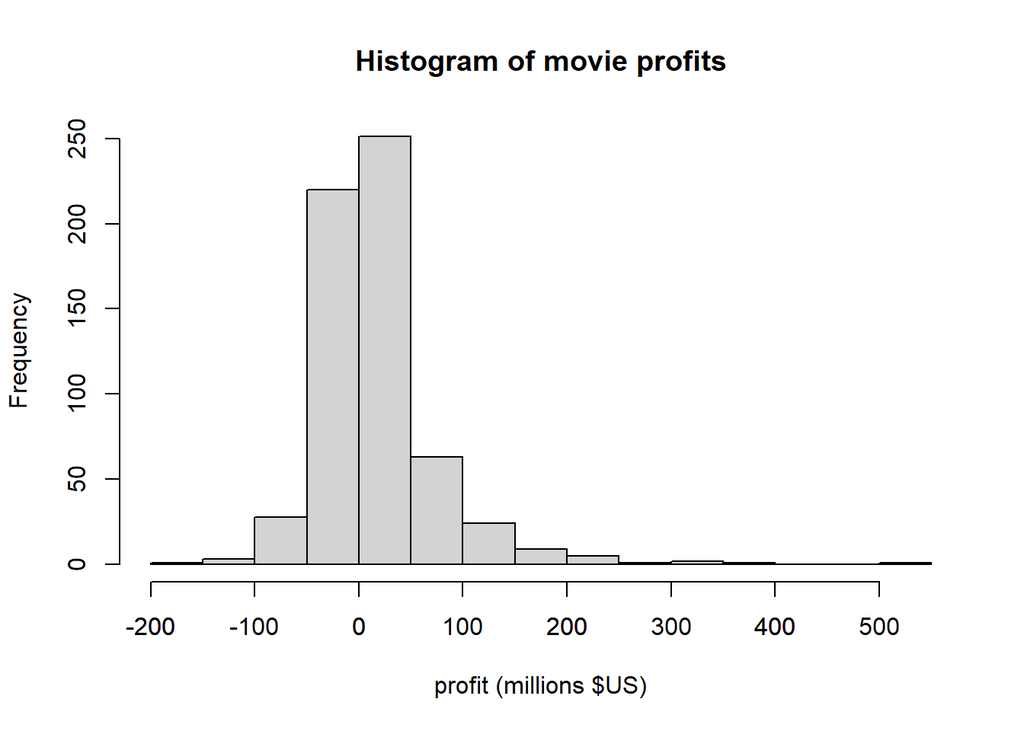

```r
#Creating a histogram of profit with a main label and a y label
hist(movie$profit, main="Histogram of movie profits", xlab = "profit (millions $US)")
#Specify the axis range and ticks
axis(side=1,at=seq(-200,550,100))
```

#### Table 1.1 R Code - Descriptive Statistics

```r
# Loading misty package
library(misty)
# misty::descript() is a handy function for obtaining descriptive statistics.
#Here, instead of accepting the default output,
#we are instead using the print argument to request the mean,
#standard deviation, mimimum, 25th percentile, median,
#75th percentile, maximum, IQR, skewness, and kurtosis:
descript(movie, print= c('m','sd','min','p25','med','p75',
                                'max','iqr','skew','kurt'))
```

```
 Descriptive Statistics

  Variable       M    SD     Min     p25     Med     p75     Max   IQR Skew  Kurt
   year    2009.97  1.41 2008.00 2009.00 2010.00 2011.00 2012.00  2.00 0.01 -1.29
   gross     75.82 82.64    2.78   25.53   48.24   94.84  760.51 69.30 3.01 14.02
   budget    58.20 52.17    1.00   22.00   40.00   79.00  250.00 57.00 1.60  2.09
   leng     106.89 16.73   63.00   95.00  105.00  114.00  196.00 19.00 1.20  2.41
   score     47.19 25.78    0.00   25.00   45.00   68.00   99.00 43.00 0.16 -1.07
   profit    17.62 60.51 -176.92  -12.84    6.89   32.54  523.51 45.38 2.59 13.81
```

```r
#Additional descriptive statistics (e.g., range)
#can be obtained by changing the print argument to print = "all".
```

### Developing the Simple Regression Model

#### Figure 1.2 R Code - Correlation Between Profit and Review Score and Scatterplot

We can visualize the relationship between review and profit with a scatterplot:

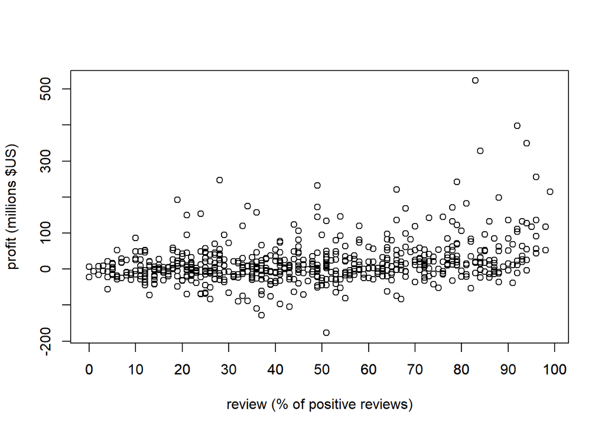

```r
#Create a scatterplot of y ~ x with x- and y-axis labels.
plot(movie$profit ~ movie$score, xlab="review (% of positive reviews)",
     ylab="profit (millions $US)")

#Specify axis range and ticks.
axis(side=1,at=seq(0,100,10))
```

#### Product-moment Covariance and Pearson Correlation

```r
#Sample product-moment covariance between profit and review
cov(movie$profit, movie$score)
```

```
[1] 467.9771
```

```r
#Pearson product-moment correlation between profit and review
cor.test(movie$profit, movie$score)
```

```
    Pearson's product-moment correlation

data:  movie$profit and movie$score
t = 7.7479, df = 607, p-value = 3.942e-14
alternative hypothesis: true correlation is not equal to 0
95 percent confidence interval:
 0.2259278 0.3706102
sample estimates:
      cor
0.2999932
```

```r
#The cor.test() output provides the correlation (.2999)
#as well as a significance test and confidence interval for the correlation.
```

#### Alternate Scatterplot with LOESS Line

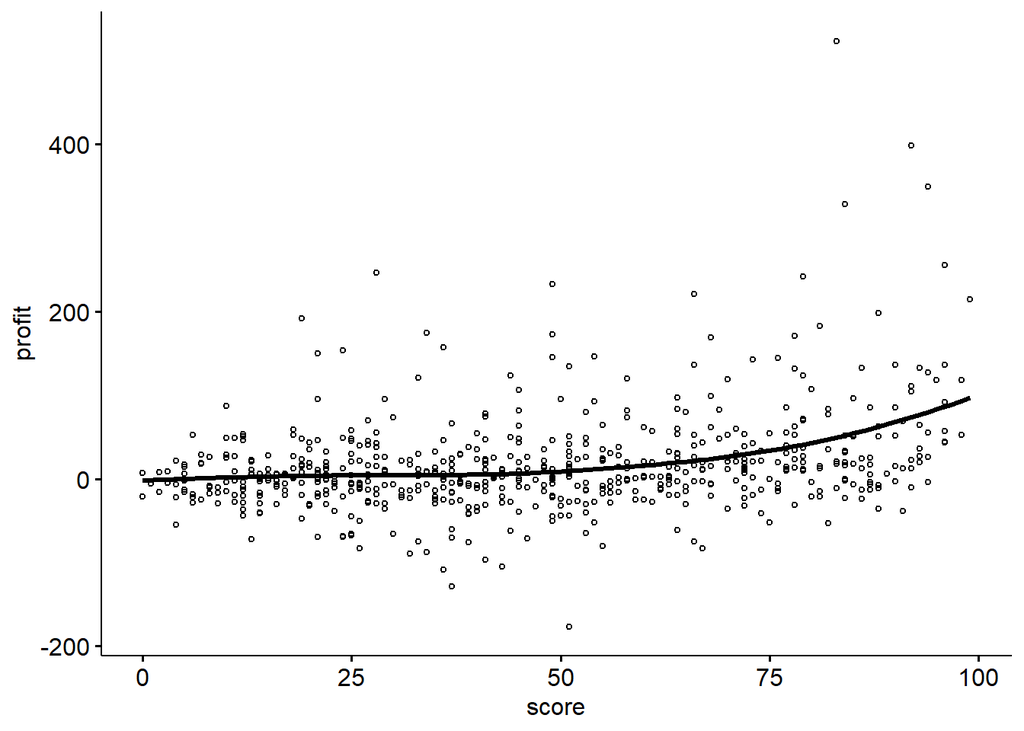

```r
#Loading ggpubr package
library(ggpubr)

#Scatterplots can also be created with the ggscatter function.
ggscatter(movie, y="profit", x="score", add = c("loess"), size = 1, shape=1)
```

#### Figure 1.3 R Code - Examining the Simple Model

We can assess the appropriateness of a linear model by plotting the relationship between the two variables and comparing the linear regression line with the non-parametric “LOWESS” (or “LOESS”) curve.

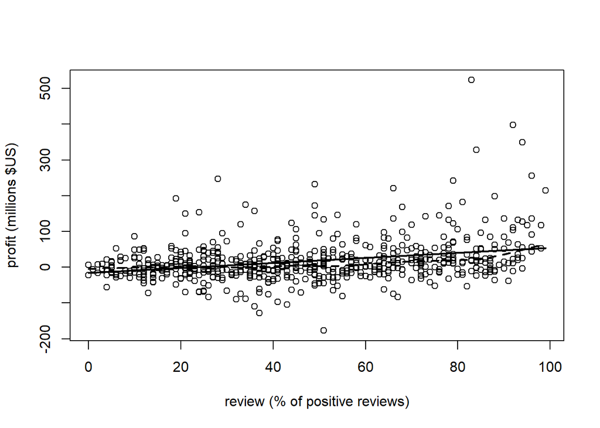

```r
#Loading the car package
library(car)

#Create a scatterplot with a nonparametric LOWESS curve ("smooth" argument)
#and a regression line ("regLine=TRUE")
scatterplot(profit ~ score, boxplot=F, smooth=list(var=F, span=.2), regLine=T, data=movie,
            col="black", grid=F, xlab="review (% of positive reviews)",
            ylab="profit (millions $US)")
```

### Simple linear regression: Model estimation

```r
#Create the simple linear model using lm(y~x)
#and saving it as an object called "movieMod"
movieMod <- lm(profit ~ score, data=movie)

#Obtain model output
summary(movieMod)
```

```
Call:
lm(formula = profit ~ score, data = movie)

Residuals:
    Min      1Q  Median      3Q     Max
-197.23  -29.34   -7.03   17.35  480.67

Coefficients:
             Estimate Std. Error t value Pr(>|t|)
(Intercept) -15.60263    4.88577  -3.193  0.00148 **
score         0.70407    0.09087   7.748 3.94e-14 ***
---
Signif. codes:  0 '***' 0.001 '**' 0.01 '*' 0.05 '.' 0.1 ' ' 1

Residual standard error: 57.77 on 607 degrees of freedom
Multiple R-squared:   0.09, Adjusted R-squared:  0.0885
F-statistic: 60.03 on 1 and 607 DF,  p-value: 3.942e-14
```

```r
#Key pieces of information in the output above include the slope estimate (0.70)
#and multiple R-squared (.09; explained further in Chapter 2).
#Notice that the significance test for the slope estimate (t = 7.75, p = 3.94e-14)
#obtains the EXACT same p-value as the significance test for R-squared (F = 60.03, p = 3.94e-14).
#When a regression model includes only one regressor,
#the t-test of the slope estimate and the F-test of R-squared are equivalent, with F = t^2.

#Obtain confidence intervals for estimates
confint(movieMod)
```

```
                  2.5 %     97.5 %
(Intercept) -25.1976889 -6.0075643
score         0.5256094  0.8825353
```

```r
#The confint() function produces 95% confidence intervals by default.
#The 95% CI for the slope is (0.5256, 0.8825)

#We can change the confidence level using the level= option.
confint(movieMod, level = .99)
```

```
                  0.5 %    99.5 %
(Intercept) -28.2272232 -2.978030
score         0.4692617  0.938883
```

```r
#The 99% CI for the slope is (0.469, 0.939)
```

### Simple regression with a binary regressor

Simple regression models can also have a binary regressor (i.e. a variable with only two values). Here we will explore how profit differs between 2008 and 2009.

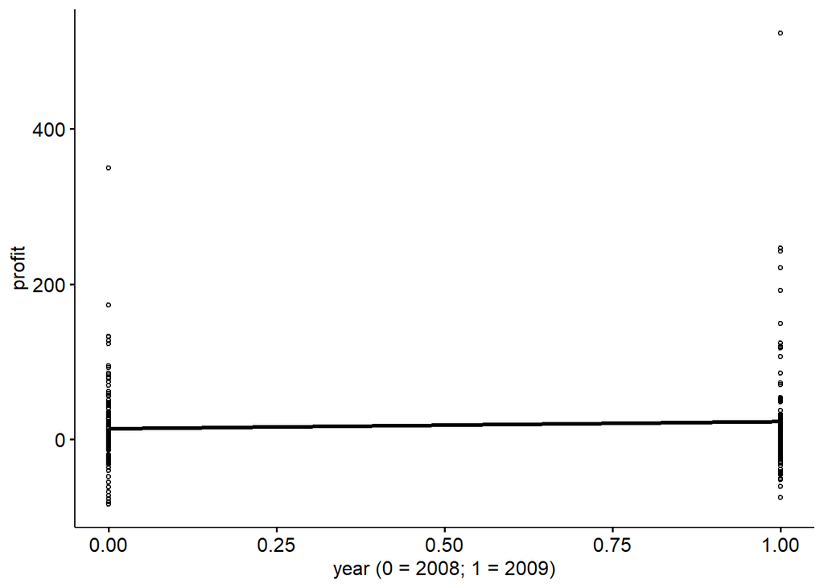

```r
#Create data frame only containing movies released before 2010 (i.e., 2008 or 2009)
newer <- subset(movie, year < 2010)
#Create a "dummy variable" for year where 0=2008 and 1 = 2009
newer$dum1 <- ifelse(newer$year==2008, 0, 1)

#Create scatterplot of relationship between year (dummy coded) and profit,
#including a regression line to scatterplot with "add = "reg.line"" argument.
ggscatter(newer, y="profit", x="dum1", add = "reg.line", size = 1, shape=1,
          xlab = "year (0 = 2008; 1 = 2009)")
```

```r
#The regression line connects the mean profit in 2008 to the mean profit in 2009.
```

### **Linearity**

Figure 1.3 showed that the association between review and profit is approximately linear. For an example of a nonlinear association, let’s access the “Salaries” data from the carData package:

```r
data("Salaries")
```

A description of the dataset can be accessed with the ‘?’ operator:

```r
?Salaries
```

A scatterplot with a LOWESS curve shows that professor salary has a strong nonlinear association with years since PhD:

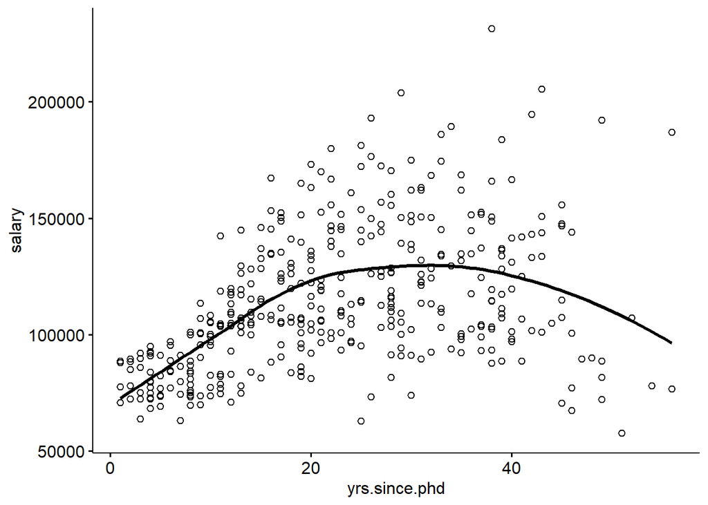

```r
ggscatter(Salaries, y="salary", x="yrs.since.phd", add = "loess", shape=1)
```

### Distribution of residuals

#### Figure 1.5 R Code - Examining Residuals

Here we can create a quantile-quantile plot, or Q-Q plot, of the residuals of the model against the quantiles of a normal distribution.

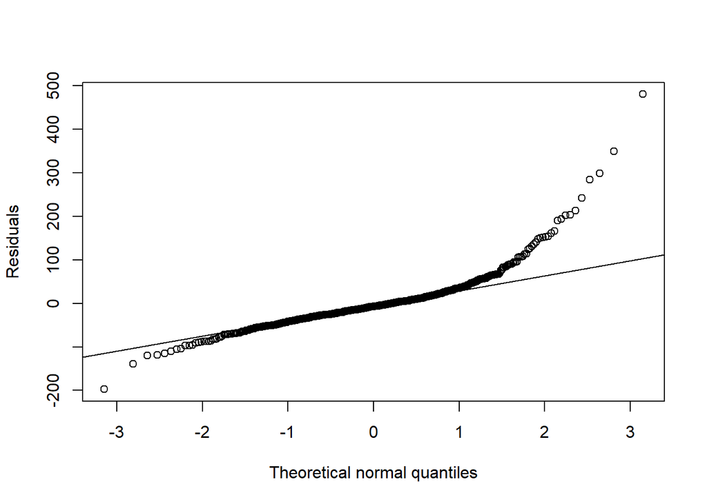

```r
#Create a Q-Q plot with a diagonal reference line.
qqnorm(resid(movieMod), main="", ylab = "Residuals", xlab = "Theoretical normal quantiles")
qqline(resid(movieMod))
```

### Homogeneity of variance

#### Figure 1.6 R Code - Examining Homoscedasticity

To assess homoscedasticity we can plot the reviews and against the model residuals and examine the spread of the data.

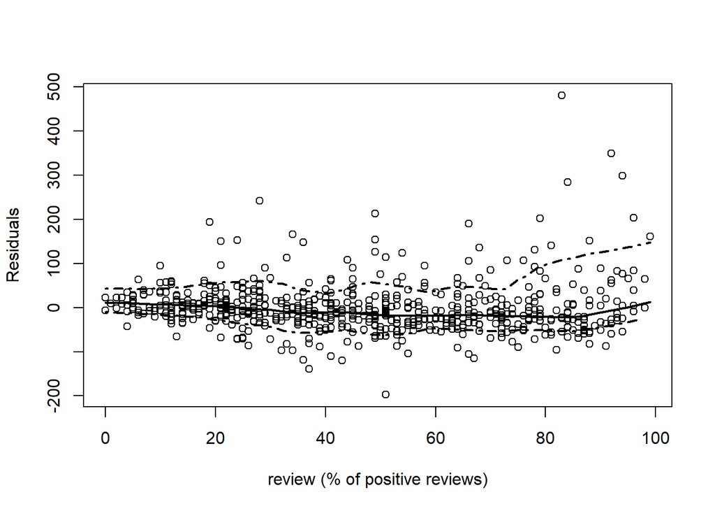

```r
#Create a scatterplot of the relationship between model residuals and movie reviews.
scatterplot(resid(movieMod) ~ score, boxplot=F, smooth=list(var=T, span=.2, style="lines",
            lty.smooth=1), regLine=F, data=movie, col="black", grid=F,
            xlab="review (% of positive reviews)", ylab="Residuals")
```

```r
#As explained in the text, the dashed lines are formed from the root-mean-square
#positive and negative residuals from the LOWESS curve
#to give a graphical summary of the spread of the data from low to high review scores.
```